# NYPD Shooting Incident Data Report

Marcus J. McDonald

2025-05-24

## Introduction

This document provides some analysis of the shooting incident data provided by the New York Police Department (NYPD). The CSV file link for the dataset was retrieved on May 23, 2025 via [Data.gov](https://catalog.data.gov/dataset/nypd-shooting-incident-data-historic). The Dataset provides a breakdown of every shooting incident that occurred in New York City (NYC) from 2006 through the end of the previous calendar year.

## Data Overview

According to the site description, this data is “manually extracted every quarter and reviewed by the Office of Management Analysis and Planning before being posted on the NYPD website.” Each record represents a shooting incident in NYC and includes the following information:

```r
summary(nypd_shooting_incidents)
```

```
##   INCIDENT_KEY        OCCUR_DATE          OCCUR_TIME
##  Min.   :  9953245   Length:29744       Min.   :00:00:00.000000
##  1st Qu.: 67321140   Class :character   1st Qu.:03:30:45.000000
##  Median :109291972   Mode  :character   Median :15:15:00.000000
##  Mean   :133850951                      Mean   :12:46:10.874798
##  3rd Qu.:214741917                      3rd Qu.:20:44:00.000000
##  Max.   :299462478                      Max.   :23:59:00.000000
##
##      BORO           LOC_OF_OCCUR_DESC     PRECINCT      JURISDICTION_CODE
##  Length:29744       Length:29744       Min.   :  1.00   Min.   :0.0000
##  Class :character   Class :character   1st Qu.: 44.00   1st Qu.:0.0000
##  Mode  :character   Mode  :character   Median : 67.00   Median :0.0000
##                                        Mean   : 65.23   Mean   :0.3181
##                                        3rd Qu.: 81.00   3rd Qu.:0.0000
##                                        Max.   :123.00   Max.   :2.0000
##                                                         NA's   :2
##  LOC_CLASSFCTN_DESC LOCATION_DESC      STATISTICAL_MURDER_FLAG
##  Length:29744       Length:29744       Mode :logical
##  Class :character   Class :character   FALSE:23979
##  Mode  :character   Mode  :character   TRUE :5765
##
##
##
##
##  PERP_AGE_GROUP       PERP_SEX          PERP_RACE         VIC_AGE_GROUP
##  Length:29744       Length:29744       Length:29744       Length:29744
##  Class :character   Class :character   Class :character   Class :character
##  Mode  :character   Mode  :character   Mode  :character   Mode  :character
##
##
##
##
##    VIC_SEX            VIC_RACE           X_COORD_CD        Y_COORD_CD
##  Length:29744       Length:29744       Min.   : 914928   Min.   :125757
##  Class :character   Class :character   1st Qu.:1000094   1st Qu.:183042
##  Mode  :character   Mode  :character   Median :1007826   Median :195506
##                                        Mean   :1009442   Mean   :208722
##                                        3rd Qu.:1016739   3rd Qu.:239980
##                                        Max.   :1066815   Max.   :271128
##
##     Latitude       Longitude        Lon_Lat
##  Min.   :40.51   Min.   :-74.25   Length:29744
##  1st Qu.:40.67   1st Qu.:-73.94   Class :character
##  Median :40.70   Median :-73.91   Mode  :character
##  Mean   :40.74   Mean   :-73.91
##  3rd Qu.:40.83   3rd Qu.:-73.88
##  Max.   :40.91   Max.   :-73.70
##  NA's   :97      NA's   :97
```

The **pre-cleaning** format is as follows:

```r
head(nypd_shooting_incidents)
```

```
## # A tibble: 6 × 21
##   INCIDENT_KEY OCCUR_DATE OCCUR_TIME BORO     LOC_OF_OCCUR_DESC PRECINCT
##          <dbl> <chr>      <time>     <chr>    <chr>                <dbl>
## 1    231974218 08/09/2021 01:06      BRONX    <NA>                    40
## 2    177934247 04/07/2018 19:48      BROOKLYN <NA>                    79
## 3    255028563 12/02/2022 22:57      BRONX    OUTSIDE                 47
## 4     25384540 11/19/2006 01:50      BROOKLYN <NA>                    66
## 5     72616285 05/09/2010 01:58      BRONX    <NA>                    46
## 6     85875439 07/22/2012 21:35      BRONX    <NA>                    42
## # ℹ 15 more variables: JURISDICTION_CODE <dbl>, LOC_CLASSFCTN_DESC <chr>,
## #   LOCATION_DESC <chr>, STATISTICAL_MURDER_FLAG <lgl>, PERP_AGE_GROUP <chr>,
## #   PERP_SEX <chr>, PERP_RACE <chr>, VIC_AGE_GROUP <chr>, VIC_SEX <chr>,
## #   VIC_RACE <chr>, X_COORD_CD <dbl>, Y_COORD_CD <dbl>, Latitude <dbl>,
## #   Longitude <dbl>, Lon_Lat <chr>
```

## Tidy and Transform

Below are the steps I took to clean the data. Each step taken is broken out in to the corresponding individual steps. It is known to the author of this document that these steps could have been aggregated into a single tidy command. However, I am making an attempt to show my process here.

### Step 1: Fix Date and time

```r
nypd_shooting_incidents <- nypd_shooting_incidents %>%
  mutate(
    OCCUR_DATE = mdy(OCCUR_DATE),
    OCCUR_TIME = as_hms(OCCUR_TIME)
  )
```

```r
nypd_shooting_incidents <- nypd_shooting_incidents %>%
  mutate(
    across(
      c(PERP_SEX, PERP_RACE, PERP_AGE_GROUP), ~ na_if(.x, "(null)")
    ) %>%
      mutate(across(everything(), ~ na_if(.x, "UNKNOWN")))
  )
```

### Step 3: Convert categorical data to factors

```r
nypd_shooting_incidents <- nypd_shooting_incidents %>%
  mutate(
    across(
      c(BORO, LOC_OF_OCCUR_DESC, LOC_CLASSFCTN_DESC, LOCATION_DESC,
        PERP_AGE_GROUP, PERP_SEX, PERP_RACE,
        VIC_AGE_GROUP, VIC_SEX, VIC_RACE),
      as.factor
    )
  )
```

### Step 4: Drop Coordinates, Latitude, Longitude, etc.

```r
nypd_shooting_incidents <- nypd_shooting_incidents %>%
  select(-c(X_COORD_CD, Y_COORD_CD, Latitude, Longitude, Lon_Lat))
```

### Final: NYPD Shooting Incident Data (Clean)

```r
summary(nypd_shooting_incidents)
```

```
##   INCIDENT_KEY         OCCUR_DATE           OCCUR_TIME
##  Min.   :  9953245   Min.   :2006-01-01   Min.   :00:00:00.000000
##  1st Qu.: 67321140   1st Qu.:2009-10-29   1st Qu.:03:30:45.000000
##  Median :109291972   Median :2014-03-25   Median :15:15:00.000000
##  Mean   :133850951   Mean   :2014-10-31   Mean   :12:46:10.874798
##  3rd Qu.:214741917   3rd Qu.:2020-06-29   3rd Qu.:20:44:00.000000
##  Max.   :299462478   Max.   :2024-12-31   Max.   :23:59:00.000000
##
##             BORO       LOC_OF_OCCUR_DESC    PRECINCT      JURISDICTION_CODE
##  BRONX        : 8834   INSIDE :  682     Min.   :  1.00   Min.   :0.0000
##  BROOKLYN     :11685   OUTSIDE: 3466     1st Qu.: 44.00   1st Qu.:0.0000
##  MANHATTAN    : 3977   NA's   :25596     Median : 67.00   Median :0.0000
##  QUEENS       : 4426                     Mean   : 65.23   Mean   :0.3181
##  STATEN ISLAND:  822                     3rd Qu.: 81.00   3rd Qu.:0.0000
##                                          Max.   :123.00   Max.   :2.0000
##                                                           NA's   :2
##   LOC_CLASSFCTN_DESC                   LOCATION_DESC   STATISTICAL_MURDER_FLAG
##  STREET    : 2639    MULTI DWELL - PUBLIC HOUS: 5188   Mode :logical
##  HOUSING   :  643    MULTI DWELL - APT BUILD  : 3042   FALSE:23979
##  DWELLING  :  341    (null)                   : 2526   TRUE :5765
##  COMMERCIAL:  276    PVT HOUSE                : 1010
##  OTHER     :   74    GROCERY/BODEGA           :  775
##  (Other)   :  175    (Other)                  : 2226
##  NA's      :25596    NA's                     :14977
##  PERP_AGE_GROUP  PERP_SEX                              PERP_RACE
##  18-24  : 6630   F   :  461   AMERICAN INDIAN/ALASKAN NATIVE:    2
##  25-44  : 6342   M   :16845   ASIAN / PACIFIC ISLANDER      :  184
##  <18    : 1805   U   : 1500   BLACK                         :12323
##  45-64  :  775   NA's:10938   BLACK HISPANIC                : 1487
##  65+    :   67                WHITE                         :  305
##  (Other):    5                WHITE HISPANIC                : 2667
##  NA's   :14120                NA's                          :12776
##  VIC_AGE_GROUP   VIC_SEX                             VIC_RACE
##  <18    : 3081   F: 2891   AMERICAN INDIAN/ALASKAN NATIVE:   13
##  1022   :    1   M:26841   ASIAN / PACIFIC ISLANDER      :  478
##  18-24  :10677   U:   12   BLACK                         :20999
##  25-44  :13563             BLACK HISPANIC                : 2930
##  45-64  : 2118             UNKNOWN                       :   72
##  65+    :  236             WHITE                         :  741
##  UNKNOWN:   68             WHITE HISPANIC                : 4511
```

The **post-cleaning** format is as follows:

```r
head(nypd_shooting_incidents)
```

```
## # A tibble: 6 × 16
##   INCIDENT_KEY OCCUR_DATE OCCUR_TIME BORO     LOC_OF_OCCUR_DESC PRECINCT
##          <dbl> <date>     <time>     <fct>    <fct>                <dbl>
## 1    231974218 2021-08-09 01:06      BRONX    <NA>                    40
## 2    177934247 2018-04-07 19:48      BROOKLYN <NA>                    79
## 3    255028563 2022-12-02 22:57      BRONX    OUTSIDE                 47
## 4     25384540 2006-11-19 01:50      BROOKLYN <NA>                    66
## 5     72616285 2010-05-09 01:58      BRONX    <NA>                    46
## 6     85875439 2012-07-22 21:35      BRONX    <NA>                    42
## # ℹ 10 more variables: JURISDICTION_CODE <dbl>, LOC_CLASSFCTN_DESC <fct>,
## #   LOCATION_DESC <fct>, STATISTICAL_MURDER_FLAG <lgl>, PERP_AGE_GROUP <fct>,
## #   PERP_SEX <fct>, PERP_RACE <fct>, VIC_AGE_GROUP <fct>, VIC_SEX <fct>,
## #   VIC_RACE <fct>
```

## Visualizations and Analysis

### Question 1: What is the distribution of victim age groups by gender?

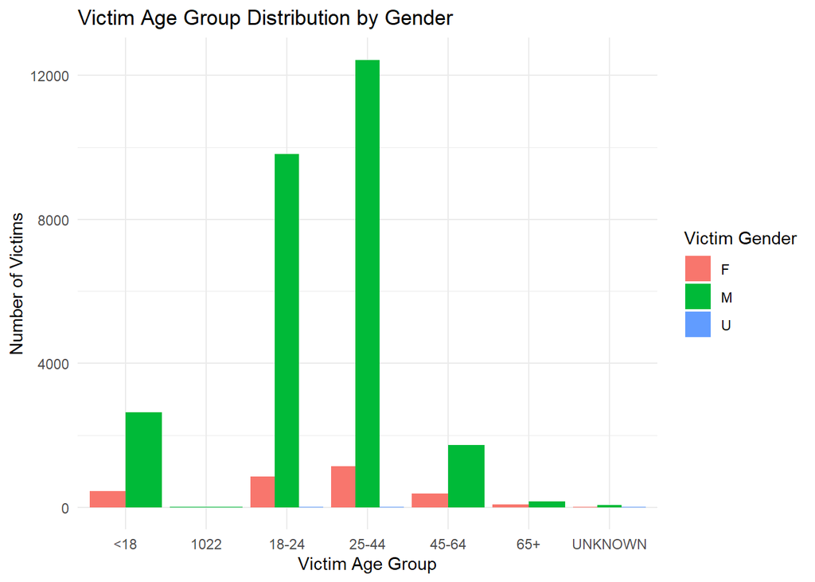

```r
# Question 1: What is the distribution of victim age groups by gender?
victim_age_sex <- nypd_shooting_incidents %>%
  filter(!is.na(VIC_AGE_GROUP), !is.na(VIC_SEX)) %>%
  count(VIC_SEX, VIC_AGE_GROUP)

ggplot(victim_age_sex, aes(x = VIC_AGE_GROUP, y = n, fill = VIC_SEX)) +
  geom_col(position = "dodge") +
  labs(
    title = "Victim Age Group Distribution by Gender",
    x = "Victim Age Group",
    y = "Number of Victims",
    fill = "Victim Gender"
  ) +
  theme_minimal()
```

From the data we can conclude that most of the shooting incidents in the NYPD Shooting Incident Report affects males in the two groups: 18-24 and 25-44 predominately. This trend suggests that young to middle-aged males are at highest risk of gun violence in NYC versus other demographics.

### Question 2: How have shootings varied over time by borough?

This question looks at the raise and fall of shootings by borough. This plot helps us see at a glance whether or not shootings are going up or down.

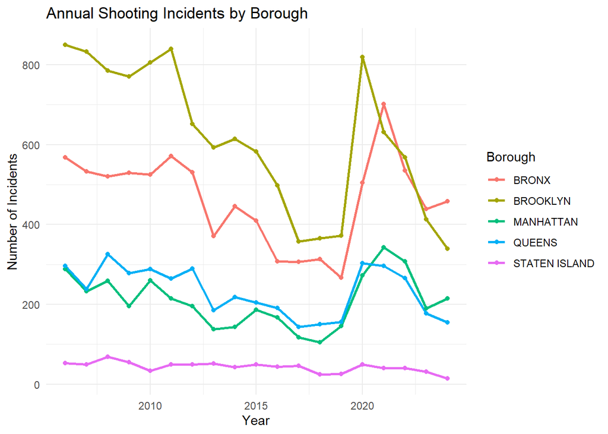

```r
# Question 2: How have shootings varied over time by borough?
shootings_by_year_boro <- nypd_shooting_incidents %>%
  mutate(year = year(OCCUR_DATE)) %>%
  filter(!is.na(BORO)) %>%
  count(year, BORO)

ggplot(shootings_by_year_boro, aes(x = year, y = n, color = BORO)) +
  geom_line(size = 1) +
  geom_point() +
  labs(
    title = "Annual Shooting Incidents by Borough",
    x = "Year",
    y = "Number of Incidents",
    color = "Borough"
  ) +
  theme_minimal()
```

From this plot we can see that shooting incidents are not evenly distributed across New York City. Also, we can see that even though Brooklyn has had a higher number of shooting incidents in the past, it looks like in recent years they have seen a fall in shooting incidences. In the latest year data we see that the Bronx has seen an uptick in shooting incidences. From these facts and noticing the slight uptick in shootings for the Bronx we might ask the follow-up question below.

### Follow-on Question: How do time and location affect shootings in the Bronx?

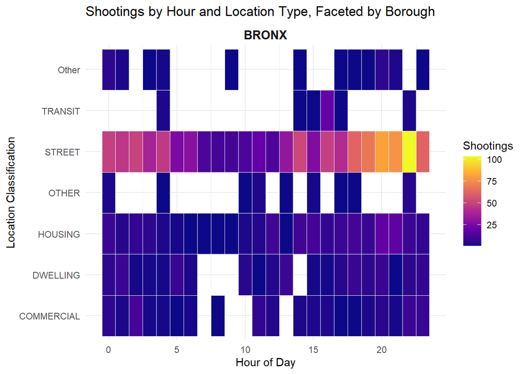

```r
# How do time and location affect shootings in the Bronx?
location_time_boro <- nypd_shooting_incidents %>%
  filter(BORO=="BRONX", !is.na(OCCUR_TIME), !is.na(LOC_CLASSFCTN_DESC)) %>%
  mutate(
    hour = hour(OCCUR_TIME),
    LOC_CLASSFCTN_DESC = fct_lump_n(LOC_CLASSFCTN_DESC, n = 6)  # Top 6 + "Other"
  ) %>%
  count(BORO, hour, LOC_CLASSFCTN_DESC)

ggplot(location_time_boro, aes(x = hour, y = LOC_CLASSFCTN_DESC, fill = n)) +
  geom_tile(color = "white") +
  facet_wrap(~ BORO, ncol = 2) +
  scale_fill_viridis_c(option = "C") +
  labs(
    title = "Shootings by Hour and Location Type, Faceted by Borough",
    x = "Hour of Day",
    y = "Location Classification",
    fill = "Shootings"
  ) +
  theme_minimal() +
  theme(strip.text = element_text(size = 12, face = "bold"))
```

From the graph we can see that the majority of shootings in the Bronx happened on the street and at late hours in the night. Also, we can see on the heat map that the later hours of the day seem to be more active for shooting regardless of location but by far the most activity is seen on the street.

### One Last Follow-on Question: How do time and location affect shootings in the other Boroughs?

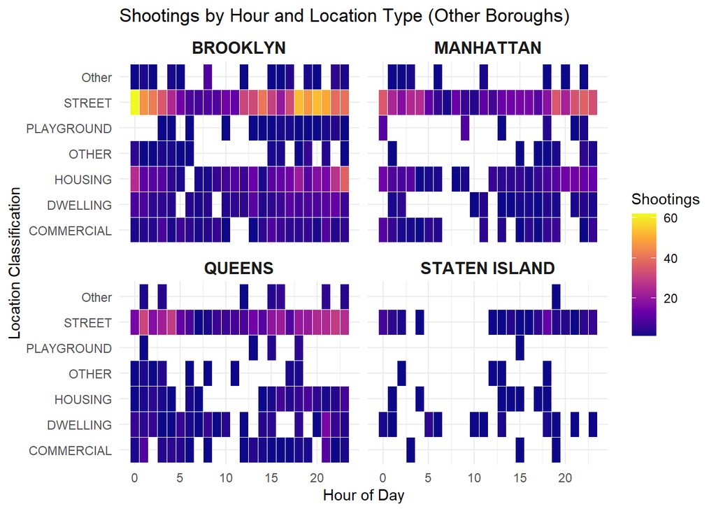

```r
library(forcats)

# Prepare the data excluding BRONX
location_time_other_boros <- nypd_shooting_incidents %>%
  filter(
    BORO != "BRONX",
    !is.na(OCCUR_TIME),
    !is.na(LOC_CLASSFCTN_DESC),
    !is.na(BORO)
  ) %>%
  mutate(
    hour = hour(OCCUR_TIME),
    LOC_CLASSFCTN_DESC = fct_lump_n(LOC_CLASSFCTN_DESC, n = 6)
  ) %>%
  count(BORO, hour, LOC_CLASSFCTN_DESC)

# Plot the heatmaps excluding BRONX
ggplot(location_time_other_boros, aes(x = hour, y = LOC_CLASSFCTN_DESC, fill = n)) +
  geom_tile(color = "white") +
  facet_wrap(~ BORO, ncol = 2) +
  scale_fill_viridis_c(option = "C") +
  labs(
    title = "Shootings by Hour and Location Type (Other Boroughs)",
    x = "Hour of Day",
    y = "Location Classification",
    fill = "Shootings"
  ) +
  theme_minimal() +
  theme(strip.text = element_text(size = 12, face = "bold"))
```

Presented above is a similar heatmaps of Shootings by hour and location for the other Boroughs. We see that that street is also the most likely place for shooting incidences to occur in most other boroughs. with similar hours being the “hottest.”

## Conclusion and Bias Identification

Analysis of NYPD shooting incident data provides us with several noticeable patterns. Firstly, reported shootings are not randomly distributed within New York City, with the highest number having occurred historically in Brooklyn. The most recent data in the report shows a decline in Brooklyn and an uptick in the Bronx.

While this dataset can be used to provide some insights into NYC shooting patterns, there are some sources of bias that should be considered regarding the dataset. Reporting bias can impact the validity of the reported incidents. The data provide could reflect more information about ares that are “over-policed,” making one group seem more responsible for shooting incidences than might otherwise be true. Also, a large proportion of entries lack demographic information, limiting any firm conclusions being drawn.

On the subject of bias and identifying bias in the data, I think a person I might have is that I tend to be very skeptical of the accuracy of the reported information. My bias might also dovetail into the over-policing idea. I can see how having pre-existing notions or beliefs about how policing is conducted can color how I view the validity of the data collected.

## Reference(s)

NYPD Shooting Incident Data (Historic). City of New York, May 24, 2025, https://data.cityofnewyork.us/api/views/833y-fsy8/rows.csv.